# Project 2 Write-Up: A Look Into Global Food Wasteage

Chi Pham

```python
import matplotlib.pyplot as plt
import numpy as np
import pandas as pd
import seaborn as sns
from sklearn.neural_network import MLPClassifier
from sklearn import model_selection, metrics, linear_model, cluster, datasets
from sklearn.preprocessing import StandardScaler, LabelEncoder
from sklearn.tree import DecisionTreeClassifier, DecisionTreeRegressor
from sklearn.ensemble import RandomForestClassifier, RandomForestRegressor
```

## Introduction to the Dataset

For this project, I will be using a synthetically generated dataset titled "[Global Food Wastage Dataset (2018-2024)](https://www.kaggle.com/datasets/atharvasoundankar/global-food-wastage-dataset-2018-2024?select=global_food_wastage_dataset.csv)" by Atharva Soundankar from Kaggle. This dataset includes **5000 rows** of data with **8 variables** that reflect data collected by world organizations such as the **Food and Agriculture Organization of the United Nations** (FAO) and the **United Nations Environment Programme** (UNEP).

```python
foodwaste = pd.read_csv("global_food_wastage_dataset.csv")
foodwaste.info()
```

```
<class 'pandas.core.frame.DataFrame'>
RangeIndex: 5000 entries, 0 to 4999
Data columns (total 8 columns):
 #   Column                     Non-Null Count  Dtype
---  ------                     --------------  -----
 0   Country                    5000 non-null   object
 1   Year                       5000 non-null   int64
 2   Food Category              5000 non-null   object
 3   Total Waste (Tons)         5000 non-null   float64
 4   Economic Loss (Million $)  5000 non-null   float64
 5   Avg Waste per Capita (Kg)  5000 non-null   float64
 6   Population (Million)       5000 non-null   float64
 7   Household Waste (%)        5000 non-null   float64
dtypes: float64(5), int64(1), object(2)
memory usage: 312.6+ KB
```

```python
foodwaste.describe(include="all")
```

|  | Country | Year | Food Category | Total Waste (Tons) | Economic Loss (Million $) | Avg Waste per Capita (Kg) | Population (Million) | Household Waste (%) |
| --- | --- | --- | --- | --- | --- | --- | --- | --- |
| count | 5000 | 5000.000000 | 5000 | 5000.000000 | 5000.000000 | 5000.00000 | 5000.000000 | 5000.000000 |
| unique | 20 | NaN | 8 | NaN | NaN | NaN | NaN | NaN |
| top | Germany | NaN | Prepared Food | NaN | NaN | NaN | NaN | NaN |
| freq | 287 | NaN | 711 | NaN | NaN | NaN | NaN | NaN |
| mean | NaN | 2021.015600 | NaN | 25061.780072 | 25039.703870 | 109.46397 | 706.606416 | 50.060890 |
| std | NaN | 1.999239 | NaN | 14245.119588 | 14620.236429 | 51.93373 | 402.546464 | 11.596203 |
| min | NaN | 2018.000000 | NaN | 502.610000 | 406.690000 | 20.09000 | 11.290000 | 30.020000 |
| 25% | NaN | 2019.000000 | NaN | 12783.737500 | 12612.477500 | 64.05000 | 350.602500 | 40.012500 |
| 50% | NaN | 2021.000000 | NaN | 24865.220000 | 24428.155000 | 110.08000 | 713.530000 | 50.295000 |
| 75% | NaN | 2023.000000 | NaN | 37471.035000 | 37146.037500 | 154.52500 | 1057.255000 | 60.125000 |
| max | NaN | 2024.000000 | NaN | 49990.760000 | 59228.930000 | 199.97000 | 1399.970000 | 70.000000 |

From foodwaste.info(), the dataset is shown to contain two categorical variables and six quantitative variables. The variables and their descriptions from Kaggle are as listed:

- **Country**: name of country data originated from
- **Year**: year that the data was collected
- **Food Category**: type of food that is wasted
- **Total Waste (Tons)**: total amount of food waste in tons
- **Economic Loss (Million $)**: estimated financial loss from food waste in millions of dollars
- **Avg Waste per Capita (Kg)**: average food waste generated per person in kilograms
- **Population (Million)**: population of country in millions
- **Household Waste (%)**: the percentage of food waste generated from households

From the summary of the quantitative variables in the dataset, the categorical variables **Country** and **Food Category** contain 20 and 8 unique values respectively, which means that the dataset contains food waste data from 20 different countries, where each country's data is further split into 8 different food categories. The summary also shows that the mean household waste is approximately 50% with a standard deviation of 11.60%, where the highest household waste being produced is 70% and the lowest is 30%. The household waste reaching 70% for one or more food categories and country is concerning. What is more concerning is that the highest average waste produced per person is 199.97kg compared to the lowest average waste produced per person being 20.09kg. These values show that a concerning amount and percentage of food is wasted every year for each household and person. This is reflected in the summary of **Economic Loss (Million $)**.

Listed below are the names of each country and food category used in the dataset.

```python
print("List of Countries:", foodwaste["Country"].unique(), "\n")
print("List of Food Categories:", foodwaste["Food Category"].unique())
```

```
List of Countries: ['Australia' 'Indonesia' 'Germany' 'France' 'India' 'China' 'UK'
 'South Africa' 'Japan' 'USA' 'Brazil' 'Saudi Arabia' 'Italy' 'Spain'
 'Mexico' 'Argentina' 'Canada' 'South Korea' 'Russia' 'Turkey']

List of Food Categories: ['Fruits & Vegetables' 'Prepared Food' 'Dairy Products' 'Beverages'
 'Meat & Seafood' 'Grains & Cereals' 'Frozen Food' 'Bakery Items']
```

For my analysis of the dataset and machine learning model, I will subset the dataset into 3 main subsets. One subset will contain only quantitative variables for preliminary dataset examinations. The second subset will contain data for the year 2018 and the thired subset will contain data for the year 2024. I will also be creating a copy of the original dataset to add a column to it containing the division of the total waste by the economic loss. The two subsets for the years 2018 and 2024 would be used for training to identify differences between the learning models for the respective years.

## Hypothesis Generation and Exploration

Before answering the questions I have about the dataset, I will do some preliminary dataset exploration to see the correlation and relationship between the quantitative variables.

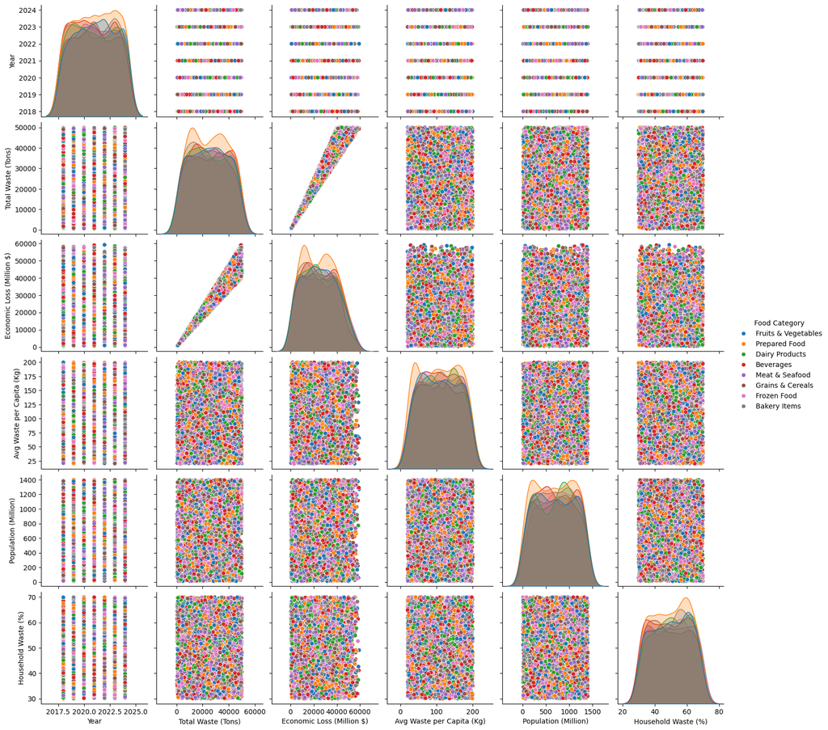

```python
sns.pairplot(data = foodwaste, hue = "Food Category")
plt.show()
```

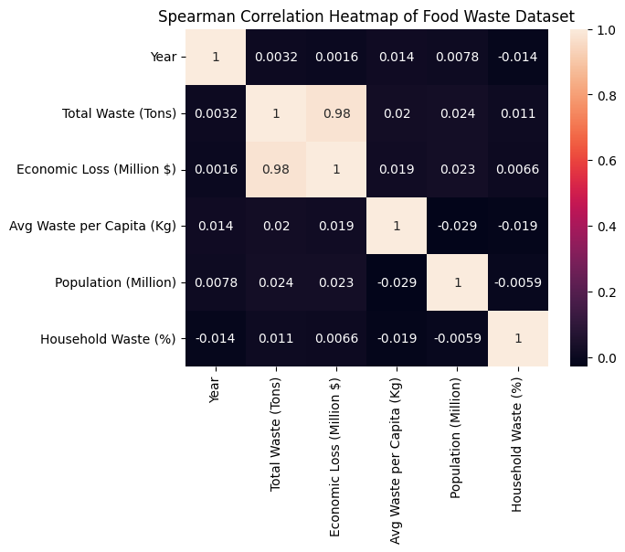

```python
foodwaste_quant = foodwaste.drop(["Country", "Food Category"], axis=1)
sns.heatmap(foodwaste_quant.corr(method="spearman"), annot=True)
plt.title("Spearman Correlation Heatmap of Food Waste Dataset")
plt.show()
```

1. How much waste does each food category generate over 7 years?

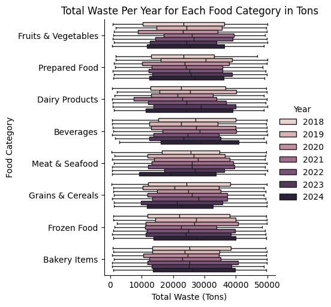

```python
sns.catplot(data = foodwaste, x = "Total Waste (Tons)", y = "Food Category", hue = "Year", kind = "box")
plt.title("Total Waste Per Year for Each Food Category in Tons")
plt.savefig("TotalWasteFoodCat.png")
plt.show()
```

From the box plots above, the categorical variable **Food Category** contains eight different categories of food that are wasted around the world each year, with seven box plots for each category showing the changes in amount of food waste over seven years. The minimum and maximum of food waste for each food category changes each year with varying changes in the interquartile range. For example, the interquartile range of *Meat & Seafood* shows a steady increase in food waste for this category from 2018 to 2022 before decreasing signficantly in 2023 and 2024. The interquartile range for *Beverages* shows that the amount of waste generated greatly increased from 2023 to 2024. This may be as a result of various factors, such as low recycling and increased consumption for beverages. This leads to my second question.

2. How does total waste affect economic loss?

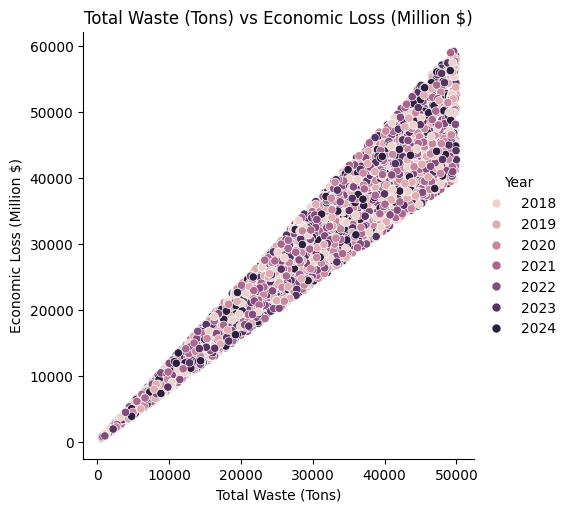

```python
sns.relplot(data = foodwaste, x = "Total Waste (Tons)", y = "Economic Loss (Million $)", hue = "Year")
plt.title("Total Waste (Tons) vs Economic Loss (Million $)")
plt.savefig("totalwasteEconomicLoss.jpg")
plt.show()
```

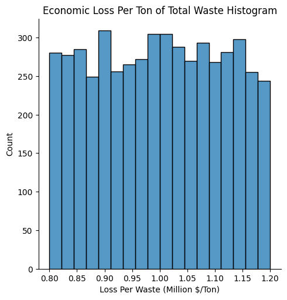

```python
foodwaste_copy = pd.read_csv("global_food_wastage_dataset.csv")
foodwaste_copy["Loss Per Waste (Million $/Ton)"] = foodwaste_copy["Economic Loss (Million $)"]/foodwaste_copy["Total Waste (Tons)"]
sns.displot(data = foodwaste_copy, x = "Loss Per Waste (Million $/Ton)", kind = "hist")
plt.title("Economic Loss Per Ton of Total Waste Histogram")
plt.savefig("histogram.png")
plt.show()
```

From the scatter plot, it can be seen that as the amount of waste increase, the amount of economic loss that a country has managing and disposing of the waste increase, regardless of the year that the data for the waste was obtained. This leads me to wonder, how much economic loss does each ton of food waste cost a country? The histogram above shows that a country loses between 0.80 million to 1.20 million dollars per ton of food waste. This leads to my concern of the increase in food waste and my final question.

3. Which countries have the greatest increase in total waste over the 7 years of data? Between 2018 and 2024?

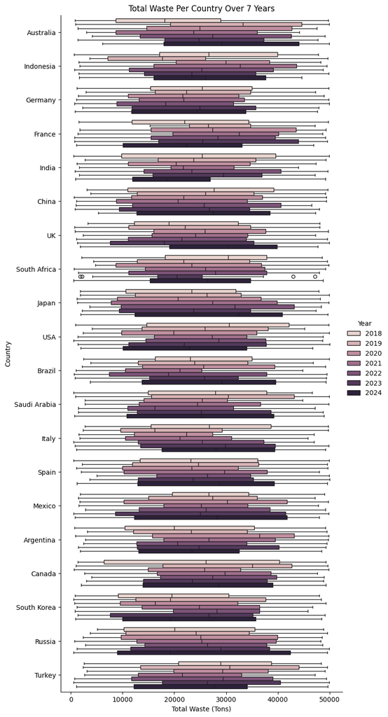

```python
sns.catplot(data = foodwaste, x = "Total Waste (Tons)", y = "Country", hue = "Year", kind = "box", height = 15, aspect = 0.5)
plt.title("Total Waste Per Country Over 7 Years")
plt.show()
```

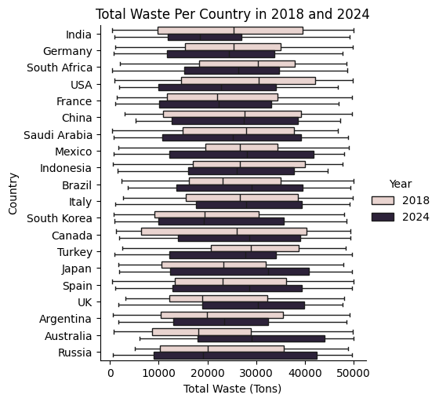

```python
subfoodwaste = foodwaste[foodwaste["Year"].isin([2018, 2024])]
sns.catplot(data = subfoodwaste, x = "Total Waste (Tons)", y = "Country", hue = "Year", kind = "box")
plt.title("Total Waste Per Country in 2018 and 2024")
plt.show()
```

The first series of box plots shows the amount of total food waste over seven years for twenty countries. From a glance, South Africa is the only country that contains outliers in the year 2023, while no other country contains any outliers. It is difficult to analyze the results of the first series of box plots as a result of the large size of the plots to accomodate all of the information, but it can be seen that most countries have varying levels of food waste each year with USA and Germany having consistent interquartile ranges for all seven years. It can also be seen that the interquartile range of total food waste in Brazil has significantly increased from 2021 to 2024.

The second series of box plots contains data for the years 2018 and 2024. From the second series of box plots, the minimum total food waste for Australia has increased in 2024 compared to 2018 while the maximum total food waste remains consistent. the box plots also indicates that the interquartile range of Australia has significantly increased in 2024, showing that the amount of total waste most of the population generates has increased, which is similarly shown for Russia, the UK, Japan, Mexico, and several other countries.

Although the amount of total food waste decreases and increases each year as shown in the first series of box plots, the amount of total food waste for several countries have increased from 2018 to 2024.

## Machine Learning

```python
sub1 = foodwaste[foodwaste["Year"] == 2018]
sub2 = foodwaste[foodwaste["Year"] == 2024]
x1 = sub1[["Total Waste (Tons)"]]
y1 = sub1[["Economic Loss (Million $)"]]
x2 = sub2[["Total Waste (Tons)"]]
y2 = sub2[["Economic Loss (Million $)"]]
```

```python
xtrain, xtest, ytrain, ytest = model_selection.train_test_split(x1, y1, test_size = 0.2, random_state = 111)
reg = linear_model.LinearRegression().fit(xtrain, ytrain)
ypredtrain = reg.predict(xtrain)
ypred = reg.predict(xtest)
print("Food Waste Data for 2018")
print("------------------------")
print("Training R2:", metrics.r2_score(ytrain, ypredtrain))
print("Testing R2:", metrics.r2_score(ytest, ypred), "\n")
print("Training RMSE:", np.sqrt(metrics.mean_squared_error(ytrain, ypredtrain)))
print("Testing RMSE:", np.sqrt(metrics.mean_squared_error(ytest, ypred)))
```

```
Food Waste Data for 2018
------------------------
Training R2: 0.9496835275646909
Testing R2: 0.9427021069964535

Training RMSE: 3247.8338742548144
Testing RMSE: 3479.92376788369
```

```python
xtrain, xtest, ytrain, ytest = model_selection.train_test_split(x2, y2, test_size = 0.2, random_state = 111)
reg = linear_model.LinearRegression().fit(xtrain, ytrain)
ypredtrain = reg.predict(xtrain)
ypred = reg.predict(xtest)
print("Food Waste Data for 2024")
print("------------------------")
print("Training R2:", metrics.r2_score(ytrain, ypredtrain))
print("Testing R2:", metrics.r2_score(ytest, ypred), "\n")
print("Training RMSE:", np.sqrt(metrics.mean_squared_error(ytrain, ypredtrain)))
print("Testing RMSE:", np.sqrt(metrics.mean_squared_error(ytest, ypred)))
```

```
Food Waste Data for 2024
------------------------
Training R2: 0.9476058770232577
Testing R2: 0.9554839990283068

Training RMSE: 3371.02873790643
Testing RMSE: 3079.173291750747
```

From the two linear regression machine learning models above, both use **Total Waste (Tons)** as the independent variable and **Economic Loss (Million $)** as the dependent model. The independent variable contains information about the total amount of food waste generated in the year 2018 and 2024, for each subset respectively, while the dependent variable contains information about the economic loss that this amount of waste generated for the same subsets.

There are some differences between the two models. The year 2018 model shows a high training R2 value with a slightly lowered testing R2 value, which is reflected in a RMSE value for training that is lower than for testing. This shows that the model is slightly overfitted for the year 2018 maching learning model. The year 2024 model shows a high training R2 value and a high testing R2 value, which indicates no overfitting or underfitting for the machine learning model for this specific year. This consequently leads to a RMSE value for training that is higher than for testing. Overall, the overfitting in the year 2018 model may be a result of less data points or how spread the data are from one another. The linear regression model is highly recommended for predicting variables that have a strong or mostly linear relationship.

```python
foodwaste = pd.get_dummies(foodwaste, columns = ["Country"])
x = foodwaste.drop(["Food Category", "Year", "Economic Loss (Million $)"], axis = 1)
y = foodwaste[["Food Category"]]
```

```python
xtrain, xtest, ytrain, ytest = model_selection.train_test_split(x, y, test_size = 0.2, random_state = 111)
clf = RandomForestClassifier(n_estimators = 100, random_state = 111).fit(xtrain, ytrain)
ypredtrain = clf.predict(xtrain)
ypredtest = clf.predict(xtest)
print("Training Accuracy Score:", metrics.accuracy_score(ytrain, ypredtrain))
print("Testing Accuracy Score:", metrics.accuracy_score(ytest, ypredtest), "\n")
print("Classification Report for Test:\n", metrics.classification_report(ytest, ypredtest))
```

```
Training Accuracy Score: 1.0
Testing Accuracy Score: 0.122

Classification Report for Test:
                      precision    recall  f1-score   support

       Bakery Items       0.13      0.14      0.14       129
          Beverages       0.14      0.11      0.12       148
     Dairy Products       0.08      0.09      0.08       116
        Frozen Food       0.09      0.11      0.10        99
Fruits & Vegetables       0.08      0.07      0.07       132
   Grains & Cereals       0.12      0.10      0.11       126
     Meat & Seafood       0.12      0.14      0.13       108
      Prepared Food       0.19      0.20      0.20       142

           accuracy                           0.12      1000
          macro avg       0.12      0.12      0.12      1000
       weighted avg       0.12      0.12      0.12      1000
```

```python
labels = np.unique(ytest)
cm = metrics.confusion_matrix(ytest, ypredtest, labels = labels)
pd.DataFrame(cm, index = labels, columns = labels)
```

|  | Bakery Items | Beverages | Dairy Products | Frozen Food | Fruits & Vegetables | Grains & Cereals | Meat & Seafood | Prepared Food |
| --- | --- | --- | --- | --- | --- | --- | --- | --- |
| Bakery Items | 18 | 20 | 17 | 16 | 13 | 10 | 18 | 17 |
| Beverages | 17 | 17 | 16 | 13 | 25 | 17 | 22 | 21 |
| Dairy Products | 16 | 16 | 10 | 19 | 14 | 12 | 15 | 14 |
| Frozen Food | 18 | 12 | 14 | 11 | 11 | 15 | 8 | 10 |
| Fruits & Vegetables | 23 | 20 | 13 | 15 | 9 | 15 | 18 | 19 |
| Grains & Cereals | 10 | 18 | 16 | 22 | 11 | 13 | 13 | 23 |
| Meat & Seafood | 15 | 6 | 17 | 10 | 17 | 10 | 15 | 18 |
| Prepared Food | 19 | 15 | 17 | 14 | 16 | 20 | 12 | 29 |

This random forest classifier uses **Food Category** as the dependent variable and the **Total Waste (Tons)**, **Country**, **Avg Waste per Capita (Kg)**, **Population (Million)**, and **Household Waste (%)** as the independent variables. The testing accuracy score of the model is significantly low compared to the training accuracy score. This indicates that the model is severly overfitted and that modifications need to be made to the model. The classification report and confusion matrix for the model indicates this overfitting. Overall, the model is not recommended until modifications are made to the dataset.

## Ethical Considerations

Since the "Global Food Wastage Dataset (2018-2024)" is a dataset that contains synthetic generations of publicly gathered and released information of a country rather than of individual persons, peoples, or groups, this dataset does not violate the ethical principles of **Respect for Persons** and **Respect for Law and Public Interest**. This dataset also does not violate the ethical principle of **Beneficence** since analyzing the trend of food waste within multiple countries does not pose risks to any groups as a result of the data being made to be publicly available.

Arguments against the use of this dataset can possibly be made by arguing the violation of the ethical principle of **Justice** due to the dataset containing information for only ***20 countries*** out of the 195 recognized countries in the world, but because there are ***over 100 countries worldwide***, the collection of food waste data of all countries may lead to a very large dataset when using the same timespan of 7 years. This makes it difficult to thoroughly analyze the vast amount of data if the data of all countries are used for this project, so this leads to minimal proof of this dataset violating the ethical principle of* *Justice**.

From this analysis, the generated dataset does not violate the ethical principles of **Respect for Persons**, **Respect for Law and Public Interest**, and **Beneficence**. Although the generated dataset may violate the ethical principle of **Justice**, but because of the public availability of the data of multiple countries that can be combined with this dataset, there is minimal evidence on this dataset's violation of **Justice**. Therefore, it can be safely concluded that this dataset does not violate any of the four ethical principles of **Respect for Persons**, **Respect for Law and Public Interest**, **Beneficence**, and **Justice**.

## Conclusion

A linear regression machine learning model is highly recommended to predict future trends between **Total Waste (Tons)** and **Economic Loss (Million $)** while a random forest classifier machine learning model is not recommended for this dataset, unless a binary variable is modified for this dataset. Data collection and usage of the data within this dataset is mostly ethical, but arguments could be made against the use of this dataset as it contains data for only 20 countries.